# If the US stock market falls, will the Korean stock market also fall?

## Introduction

Koreans have long said that when US stocks rise, Korean stocks rise, and when US stocks fall, Korean stocks fall. It is because Korea has a close relationship with the United States in trade, economy, and politics. The volume of bilateral trade between Korea and the United States reached 135.2 billion dollars in 2019, a significant increase of more than 34 percent, 100.8 billion dollars in 2011, before the conclusion of the Korea-US FTA. The United States is Korea's second largest trading partner, and Korea is the US's sixth largest trading partner.

Oh! So, can anyone get rich by trading Korean stocks compared to the US stock index? Can the US stock index really predict the Korean stock index?

In this tutorial, I will introduce the relationship between stock indices using Pearson's correlation coefficient, machine learning algorithms and analysis, and the skills needed to do this, which will lead me to conclusions on my topic.

## Data collection

### Library Used

```python
# Install pandas datareader
!pip install pandas-datareader

import pandas_datareader as pdr
import pandas as pd
import matplotlib.pyplot as plt
import seaborn as sns
import numpy as np
import scipy as sp
from scipy import stats
from datetime import datetime
from sklearn.linear_model import LinearRegression
from sklearn.model_selection import KFold
from sklearn.model_selection import cross_val_score
from sklearn.model_selection import train_test_split
```

### Load Data Using pandas-datareader

There are limited places where you can get stock data. In order to use the securities company's API, it is cumbersome to install the securities company program on the PC, so we will use Yahoo Finance's data conveniently.

```python
start = datetime(2020,1,1)
end = datetime(2020,12,31)
# Get stock item data of yahoo finance through DataReader API.
#KOrea Composite Stock Price Index(KOSPI)
df = pdr.DataReader('^KS11', 'yahoo', start, end)
df
```

| Date | High | Low | Open | Close | Volume | Adj Close |
| --- | --- | --- | --- | --- | --- | --- |
| 2020-01-02 | 2202.320068 | 2171.840088 | 2201.209961 | 2175.169922 | 494700 | 2175.169922 |
| 2020-01-03 | 2203.379883 | 2165.389893 | 2192.580078 | 2176.459961 | 631600 | 2176.459961 |
| 2020-01-06 | 2164.419922 | 2149.949951 | 2154.969971 | 2155.070068 | 592700 | 2155.070068 |
| 2020-01-07 | 2181.620117 | 2164.270020 | 2166.600098 | 2175.540039 | 568200 | 2175.540039 |
| 2020-01-08 | 2162.320068 | 2137.719971 | 2156.270020 | 2151.310059 | 913800 | 2151.310059 |
| ... | ... | ... | ... | ... | ... | ... |
| 2020-12-23 | 2769.080078 | 2716.280029 | 2737.739990 | 2759.820068 | 1121300 | 2759.820068 |
| 2020-12-24 | 2812.159912 | 2762.600098 | 2762.600098 | 2806.860107 | 1030900 | 2806.860107 |
| 2020-12-28 | 2834.590088 | 2799.560059 | 2820.949951 | 2808.600098 | 1006200 | 2808.600098 |
| 2020-12-29 | 2823.439941 | 2792.060059 | 2810.550049 | 2820.510010 | 1046800 | 2820.510010 |
| 2020-12-30 | 2878.209961 | 2809.350098 | 2820.360107 | 2873.469971 | 1074000 | 2873.469971 |

248 rows × 6 columns

The most representative stock index in Korea is the KOSPI. The three major US stock indices are the Nasdaq, Dow Jones and S&P 500. Therefore, we will use these four stock indices. If you wish, you can use other stock indices, oil prices, gold prices, etc.

```python
#Nasdaq
df2 = pdr.DataReader('^IXIC', 'yahoo', start, end)
df2
```

| Date | High | Low | Open | Close | Volume | Adj Close |
| --- | --- | --- | --- | --- | --- | --- |
| 2020-01-02 | 9093.429688 | 9010.889648 | 9039.459961 | 9092.190430 | 2848370000 | 9092.190430 |
| 2020-01-03 | 9065.759766 | 8976.429688 | 8976.429688 | 9020.769531 | 2567400000 | 9020.769531 |
| 2020-01-06 | 9072.410156 | 8943.500000 | 8943.500000 | 9071.469727 | 2788120000 | 9071.469727 |
| 2020-01-07 | 9091.929688 | 9042.549805 | 9076.639648 | 9068.580078 | 2352850000 | 9068.580078 |
| 2020-01-08 | 9168.889648 | 9059.379883 | 9068.030273 | 9129.240234 | 2464090000 | 9129.240234 |
| ... | ... | ... | ... | ... | ... | ... |
| 2020-12-24 | 12833.549805 | 12767.639648 | 12791.540039 | 12804.730469 | 3305950000 | 12804.730469 |
| 2020-12-28 | 12930.889648 | 12827.450195 | 12914.639648 | 12899.419922 | 5076340000 | 12899.419922 |
| 2020-12-29 | 12973.330078 | 12821.959961 | 12965.389648 | 12850.219727 | 4680780000 | 12850.219727 |
| 2020-12-30 | 12924.929688 | 12857.759766 | 12906.509766 | 12870.000000 | 5292210000 | 12870.000000 |
| 2020-12-31 | 12902.070312 | 12821.230469 | 12877.089844 | 12888.280273 | 4771390000 | 12888.280273 |

253 rows × 6 columns

```python
#Standard & Poor's 500 Stock Index(sap)
df3 = pdr.DataReader('^GSPC', 'yahoo', start, end)
df3
```

| Date | High | Low | Open | Close | Volume | Adj Close |
| --- | --- | --- | --- | --- | --- | --- |
| 2020-01-02 | 3258.139893 | 3235.530029 | 3244.669922 | 3257.850098 | 3458250000 | 3257.850098 |
| 2020-01-03 | 3246.149902 | 3222.340088 | 3226.360107 | 3234.850098 | 3461290000 | 3234.850098 |
| 2020-01-06 | 3246.840088 | 3214.639893 | 3217.550049 | 3246.280029 | 3674070000 | 3246.280029 |
| 2020-01-07 | 3244.909912 | 3232.429932 | 3241.860107 | 3237.179932 | 3420380000 | 3237.179932 |
| 2020-01-08 | 3267.070068 | 3236.669922 | 3238.590088 | 3253.050049 | 3720890000 | 3253.050049 |
| ... | ... | ... | ... | ... | ... | ... |
| 2020-12-24 | 3703.820068 | 3689.320068 | 3694.030029 | 3703.060059 | 1885090000 | 3703.060059 |
| 2020-12-28 | 3740.510010 | 3723.030029 | 3723.030029 | 3735.360107 | 3527460000 | 3735.360107 |
| 2020-12-29 | 3756.120117 | 3723.310059 | 3750.010010 | 3727.040039 | 3387030000 | 3727.040039 |
| 2020-12-30 | 3744.629883 | 3730.209961 | 3736.189941 | 3732.040039 | 3145200000 | 3732.040039 |
| 2020-12-31 | 3760.199951 | 3726.879883 | 3733.270020 | 3756.070068 | 3172510000 | 3756.070068 |

253 rows × 6 columns

```python
#Dow Jones Industrial Average(dow)
df4 = pdr.DataReader('^DJI', 'yahoo', start, end)
df4
```

| Date | High | Low | Open | Close | Volume | Adj Close |
| --- | --- | --- | --- | --- | --- | --- |
| 2020-01-02 | 28872.800781 | 28627.769531 | 28638.970703 | 28868.800781 | 251820000 | 28868.800781 |
| 2020-01-03 | 28716.310547 | 28500.359375 | 28553.330078 | 28634.880859 | 239590000 | 28634.880859 |
| 2020-01-06 | 28708.019531 | 28418.630859 | 28465.500000 | 28703.380859 | 252760000 | 28703.380859 |
| 2020-01-07 | 28685.500000 | 28565.279297 | 28639.179688 | 28583.679688 | 258900000 | 28583.679688 |
| 2020-01-08 | 28866.179688 | 28522.509766 | 28556.140625 | 28745.089844 | 291750000 | 28745.089844 |
| ... | ... | ... | ... | ... | ... | ... |
| 2020-12-24 | 30209.669922 | 30099.300781 | 30155.919922 | 30199.869141 | 145570000 | 30199.869141 |
| 2020-12-28 | 30525.560547 | 30283.230469 | 30283.230469 | 30403.970703 | 302490000 | 30403.970703 |
| 2020-12-29 | 30588.789062 | 30274.240234 | 30492.070312 | 30335.669922 | 357610000 | 30335.669922 |
| 2020-12-30 | 30525.349609 | 30393.039062 | 30415.089844 | 30409.560547 | 291890000 | 30409.560547 |
| 2020-12-31 | 30637.470703 | 30344.500000 | 30417.640625 | 30606.480469 | 284470000 | 30606.480469 |

253 rows × 6 columns

### Concat DataFrame

```python
data = [df["Close"], df2["Close"], df3["Close"], df4["Close"]]
#Code naming of economic indicators
headers = ["kospi", "nasdaq", "sap", "dow"]
#put it into one dataFrame
df5 = pd.concat(data, axis=1, keys=headers)
df5
```

| Date | kospi | nasdaq | sap | dow |
| --- | --- | --- | --- | --- |
| 2020-01-02 | 2175.169922 | 9092.190430 | 3257.850098 | 28868.800781 |
| 2020-01-03 | 2176.459961 | 9020.769531 | 3234.850098 | 28634.880859 |
| 2020-01-06 | 2155.070068 | 9071.469727 | 3246.280029 | 28703.380859 |
| 2020-01-07 | 2175.540039 | 9068.580078 | 3237.179932 | 28583.679688 |
| 2020-01-08 | 2151.310059 | 9129.240234 | 3253.050049 | 28745.089844 |
| ... | ... | ... | ... | ... |
| 2020-12-24 | 2806.860107 | 12804.730469 | 3703.060059 | 30199.869141 |
| 2020-12-28 | 2808.600098 | 12899.419922 | 3735.360107 | 30403.970703 |
| 2020-12-29 | 2820.510010 | 12850.219727 | 3727.040039 | 30335.669922 |
| 2020-12-30 | 2873.469971 | 12870.000000 | 3732.040039 | 30409.560547 |
| 2020-12-31 | NaN | 12888.280273 | 3756.070068 | 30606.480469 |

260 rows × 4 columns

### Remove missing data

```python
df5 = df5.fillna(method='ffill')
df5
```

| Date | kospi | nasdaq | sap | dow |
| --- | --- | --- | --- | --- |
| 2020-01-02 | 2175.169922 | 9092.190430 | 3257.850098 | 28868.800781 |
| 2020-01-03 | 2176.459961 | 9020.769531 | 3234.850098 | 28634.880859 |
| 2020-01-06 | 2155.070068 | 9071.469727 | 3246.280029 | 28703.380859 |
| 2020-01-07 | 2175.540039 | 9068.580078 | 3237.179932 | 28583.679688 |
| 2020-01-08 | 2151.310059 | 9129.240234 | 3253.050049 | 28745.089844 |
| ... | ... | ... | ... | ... |
| 2020-12-24 | 2806.860107 | 12804.730469 | 3703.060059 | 30199.869141 |
| 2020-12-28 | 2808.600098 | 12899.419922 | 3735.360107 | 30403.970703 |
| 2020-12-29 | 2820.510010 | 12850.219727 | 3727.040039 | 30335.669922 |
| 2020-12-30 | 2873.469971 | 12870.000000 | 3732.040039 | 30409.560547 |
| 2020-12-31 | 2873.469971 | 12888.280273 | 3756.070068 | 30606.480469 |

260 rows × 4 columns

### Data Scailing

Since the values of each indicator are displayed using different units, it is necessary to set them in the same unit for comparison between indicators.

If the value of the reference date is viewed as 100 based on a specific date and a relative value is obtained, scaling can be performed in the same unit.

After scaling to the value of the reference date, it can be seen that most of the values have changed to around 100.

```python
base_value = df5.iloc[int(-len(df.index) / 3)]
print(base_value)
```

```
kospi      2401.909912
nasdaq    10847.690430
sap        3331.840088
dow       27500.890625
Name: 2020-09-08 00:00:00, dtype: float64
```

```python
for stock_type in headers:
    df5[stock_type] = df5[stock_type] / base_value[stock_type] * 100

print(df5)
```

```
                 kospi      nasdaq         sap         dow
Date
2020-01-02   90.560013   83.816832   97.779305  104.974058
2020-01-03   90.613722   83.158434   97.088996  104.123467
2020-01-06   89.723185   83.625817   97.432048  104.372550
2020-01-07   90.575422   83.599178   97.158923  103.937287
2020-01-08   89.566642   84.158377   97.635239  104.524214
...                ...         ...         ...         ...
2020-12-24  116.859508  118.041076  111.141590  109.814149
2020-12-28  116.931950  118.913975  112.111026  110.556313
2020-12-29  117.427802  118.460421  111.861312  110.307955
2020-12-30  119.632712  118.642766  112.011379  110.576639
2020-12-31  119.632712  118.811284  112.732603  111.292688

[260 rows x 4 columns]
```

### Data Visualization

If the above data frame is displayed as a graph, it is as follows.

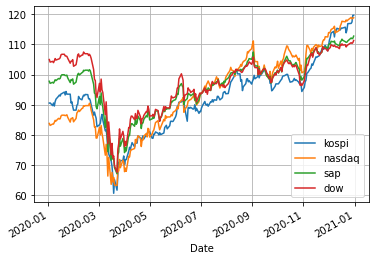

```python
df5.plot()
plt.grid()
plt.show()
```

## Exploratory Data Anlysis (EDA)

### Correlation coefficient display

The correlation coefficient described above can be output using the corr() function of the pandas data frame. Here, the Pearson correlation coefficient is used. What is Pearson's correlation coefficient? The Pearson correlation coefficient (Pearson's r) is commonly used to find the correlation between two variables.

The value of r is +1 if X and Y are exactly the same, 0 if they are completely different, and -1 if they are exactly the same in the opposite direction.

The coefficient of determination is calculated as r^2, which means the degree to which Y can be predicted from X.

In general, it is interpreted as follows.

- If r is between -1.0 and -0.7, then there is a strong negative linear relationship
- If r is between -0.7 and -0.3, then there is a pronounced negative linear relationship
- If r is between -0.3 and -0.1, a weakly negative linear relationship
- If r is between -0.1 and +0.1, a linear relationship that can be almost neglected
- If r is between +0.1 and +0.3, then there is a weak quantitative linear relationship
- If r is between +0.3 and +0.7, then there is a clear quantitative linear relationship
- If r is between +0.7 and +1.0, then there is a strong quantitative linear relationship

For more information, visit [pandas.Dataframe.corr](https://pandas.pydata.org/pandas-docs/stable/reference/api/pandas.DataFrame.corr.html) [Pearson correlation coefficient](https://en.wikipedia.org/wiki/Pearson_correlation_coefficient)

```python
print(df5.corr('pearson'))
```

```
           kospi    nasdaq       sap       dow
kospi   1.000000  0.944753  0.961082  0.894485
nasdaq  0.944753  1.000000  0.927988  0.799238
sap     0.961082  0.927988  1.000000  0.964405
dow     0.894485  0.799238  0.964405  1.000000
```

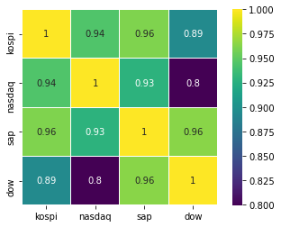

```python
#correlation coefficient has a good visual effect when using seaborn's heatmap.
sns.heatmap(df5.corr('pearson'), square=True, annot=True, cmap=plt.cm.viridis, linewidths=0.01, linecolor='white')
plt.show()
```

- From the heatmap above, we can see that KOSPI has a strong quantitative linear relationship with Nasdaq, Dow, S&P500

## Hypothesis Testing and Machine Learning

A hypothesis test evaluates two mutually exclusive statements about a population to determine which statement is best supported by the sample data.

### Null Hypothesis

The null hypothesis states that there is no relationship between the two variables being studied. One variable does not affect the other. It states the results are due to chance and are not significant in terms of supporting the idea being investigated. Thus, the null hypothesis assumes that whatever you are trying to prove did not happen.

### P-value

A p-value, or probability value, is a number describing how likely it is that the data would have occurred by random chance. The level of statistical significance is often expressed as a p-value between 0 and 1. The smaller the p-value, the stronger the evidence that you should reject the null hypothesis. A p-value less than 0.05 is statistically significant. It indicates strong evidence against the null hypothesis, as there is less than a 5% probability the null is correct. Therefore, we reject the null hypothesis, and accept the alternative hypothesis.

### Paired sampled t-test

The paired sample t-test is also called dependent sample t-test. It’s an uni variate test that tests for a significant difference between 2 related variables.

```python
#Null Hypothesis: Nasdaq has no effect on Kospi
df5[['kospi','nasdaq']].describe()
ttest,pval = stats.ttest_rel(df5['kospi'], df5['nasdaq'])
print(pval)
if pval<0.05:
    print("reject null hypothesis")
else:
    print("accept null hypothesis")
```

```
1.476405244766955e-07
reject null hypothesis
```

```python
#Null Hypothesis: s&p500 has no effect on Kospi
df5[['kospi','sap']].describe()
ttest,pval = stats.ttest_rel(df5['kospi'], df5['sap'])
print(pval)
if pval<0.05:
    print("reject null hypothesis")
else:
    print("accept null hypothesis")
```

```
2.2974429342732457e-51
reject null hypothesis
```

```python
#Null Hypothesis: Dow has no effect on Kospi
df5[['kospi','dow']].describe()
ttest,pval = stats.ttest_rel(df5['kospi'], df5['dow'])
print(pval)
if pval<0.05:
    print("reject null hypothesis")
else:
    print("accept null hypothesis")
```

```
2.820088535117444e-42
reject null hypothesis
```

- By using paired sampled t-test, we found out that p-value of all three cases are close to 0. We will reject the null hypothesis.

### Linear Regression using sklearn

Linear regression is a regression analysis technique that models the linear correlation between the dependent variable y and one or more independent variables (or explanatory variables) X. To explain this more easily, it is one of the methods of finding a straight line that explains the correlation of data.

### Split Data

train_test_split is a function in Sklearn model selection for splitting data arrays into two subsets: for training data and for testing data. Our train size and test size ratio will be 8:2.

For more information, visit [train_test_split](https://scikit-learn.org/stable/modules/generated/sklearn.model_selection.train_test_split.html)

```python
X = df5[["sap", "dow", "nasdaq"]]
y = df5["kospi"]
xTrain, xTest, yTrain, yTest = train_test_split(X, y, test_size = 0.2, random_state = 0)
```

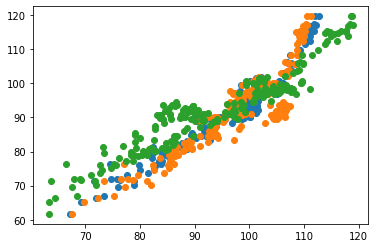

```python
#Visualize with matplotlib
plt.plot(xTrain, yTrain, 'o')
plt.show()
```

### Creating Model

LinearRegression fits a linear model with coefficients w to minimize the residual sum of squares between the observed targets in the dataset, and the targets predicted by the linear approximation.

```python
lm = LinearRegression()
line_fitter = lm
line_fitter.fit(xTrain, yTrain)
```

```
LinearRegression()
```

Now, let's put the x test data x_test and store the predicted y values as y_predict. This is to compare it with the actual correct answer in the test data later, that is, y_test.

```python
yPred = lm.predict(xTest)
```

### Visualization

The x-axis is the actual stock price and the y-axis is the predicted stock price. If the answer is correct, it will come out exactly as a line.

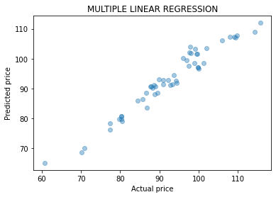

```python
plt.scatter(yTest, yPred, alpha=0.4)
plt.xlabel("Actual price")
plt.ylabel("Predicted price")
plt.title("MULTIPLE LINEAR REGRESSION")
plt.show()
```

### Checking Regression Coefficients and Constants

Multiple regression can be expressed by the following equation.

y = m1x1 + m2x2 + ... + mnxn + b

For each x, there is a regression coefficient m. If there are multimple x, there will be multiple m.

```python
#Get m
line_fitter.coef_
```

```
array([-1.40738373,  1.36927072,  0.98279702])
```

```python
#Get b
line_fitter.intercept_
```

```
2.1395581715360237
```

### Cross-Validation (k-Fold Cross Validation)

Just because you've created a model and made predictions doesn't mean the model makes good predictions. Sometimes you get good marks in training, but you get very bad marks in training. This is called overfitting. To avoid this, we don't train the entire training data set at once, but leave some and use it for testing. This method is called Cross-Validation.

It first divides the training dataset into k randomly by units called Folds. This is used to increase the reliability of performance measurements when the amount of data is insufficient. Evaluating estimator performance is a method of finding the optimal model parameter.

When k=5, i.e., after splitting the data into 5 subsets, one fold for each split is used for testing and the remaining four folds are used for training. Repeat this process to measure the accuracy for each division.

For more information, visit [cross_validation](https://scikit-learn.org/stable/modules/cross_validation.html) and [cross_val_score](https://scikit-learn.org/stable/modules/generated/sklearn.model_selection.cross_val_score.html)

```python
# create a KFold object with 5 splits
folds = KFold(n_splits = 5, shuffle = True, random_state = 100)
scores = cross_val_score(lm, xTrain, yTrain, scoring='r2', cv=folds)
#Get Accuracy
print(scores)
print(scores.mean())
```

```
[0.93488411 0.92694049 0.95393539 0.9478673  0.95019906]
0.9427652723141892
```

## Conclusion

The result of finding the Pearson correlation coefficient of the Korean stock market and the American stock market was very high. From the Cross-Validation, we can see that it can be seen that the Korean stock market and the US stock market are closely related.

This shows that the Korean stock market is closely related to the American stock market. However, since this analysis is based only on data from 2020, the results may be different if past data are included. In addition, there are many factors other than the US stock market that determine the stock price of the KOSPI. Therefore, it may be risky to invest in the KOSPI by comparing only the US stock market with the Korean stock market.

In the future, if you compare the stock markets of other countries as well as Korea and the US, interesting results may be obtained. It is also worth exploring other methods besides the linear regression used in this tutorial.